# Customer Churn Analysis of a Telecommunications company in California from April to June 2022

### Recommendations

- Regularly benchmark your offers and devices against competitors. Launch loyalty-based upgrade programs and offer exclusive bundles or limited-time promotions to counteract competitive offers.
- Invest in customer service training focused on empathy and resolution speed. Implement feedback loops (CSAT or NPS) after every interaction and reward top-performing support agents.
- Improve network infrastructure in areas with high youth density and communicate improvements transparently.
- Introduce tiered speed packages and upgrade incentives with transparent performance benchmarks.
- Design senior-friendly plans with lower pricing, no hidden fees, and simple features. Provide dedicated senior support reps.
- Offer relocation-friendly packages, onboarding rewards, and assign a dedicated onboarding support rep for new users.
- Roll out loyalty discounts, waive select long-distance/extra data fees, and solicit feedback for long-time users via surveys or interviews to uncover hidden dissatisfaction drivers.
- Provide flexible pricing plans with customizable options for singles or individuals.
- Offer family-centric plans with add-on features, and improve product usability through bundled tutorials, user guides, or home consultations.

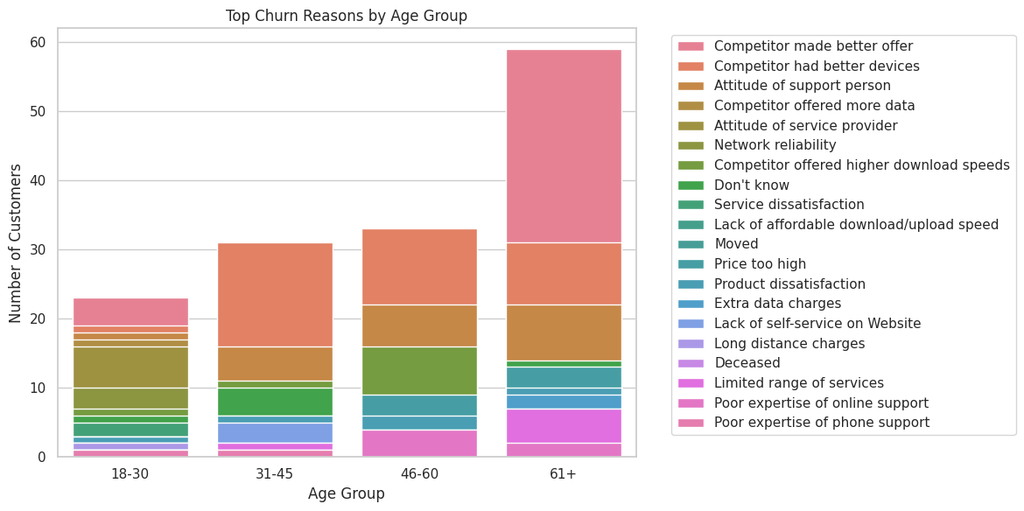

```python
import pandas as pd
import seaborn as sns
import matplotlib.pyplot as plt
from google.colab import drive

drive.mount('/content/drive', force_remount=True)
file_path = '/content/drive/MyDrive/Portfolios/Data-Analyst/Gladys-Lacia-for-Data-Analyst-role/datasets/dataset-Customer-Churn-Telco-California-from-April-to-June-2022.csv'
df = pd.read_csv(file_path, low_memory=False)
df = df.dropna(subset=['Churn Reason', 'Offer', 'Internet Type', 'Avg Monthly Long Distance Charges'])

churned_df = df[df['Customer Status'] == 'Churned'].copy()

bins_age = [0, 30, 45, 60, 100]
labels_age = ['18-30', '31-45', '46-60', '61+']
churned_df['Age Group'] = pd.cut(churned_df['Age'], bins=bins_age, labels=labels_age)

bins_tenure = [0, 12, 24, 36, 100]
labels_tenure = ['0-12', '13-24', '25-36', '37+']
churned_df['Tenure Group'] = pd.cut(churned_df['Tenure in Months'], bins=bins_tenure, labels=labels_tenure)

# ========== 1. Top Churn Reasons by Age Group ==========
age_reason = churned_df.groupby(['Age Group', 'Churn Reason'], observed=True).size().reset_index(name='Count')
top_age_reasons = age_reason.sort_values(['Age Group', 'Count'], ascending=[True, False])

plt.figure(figsize=(12, 6))
sns.barplot(data=top_age_reasons, x='Age Group', y='Count', hue='Churn Reason', dodge=False)
plt.title('Top Churn Reasons by Age Group')
plt.ylabel('Number of Customers')
plt.xticks(rotation=0)
plt.legend(bbox_to_anchor=(1.05, 1), loc='upper left')
plt.tight_layout()
plt.show()
```

```python
age_group_18_30_df = df[(df['Age'] >= 18) & (df['Age'] <= 30)]
churn_reasons_18_30 = age_group_18_30_df['Churn Reason'].value_counts()

total_churn_reasons_18_30 = churn_reasons_18_30.sum()
print("\nTotal churn reasons (customers) in age group 18–30:", total_churn_reasons_18_30)
top_reasons_18_30 = churn_reasons_18_30.head(100)
print("Top churn reasons for customers aged 18-30:\n", top_reasons_18_30)
```

```
Total churn reasons (customers) in age group 18–30: 143
Top churn reasons for customers aged 18-30:
 Churn Reason
Competitor made better offer                 23
Competitor had better devices                19
Attitude of support person                   18
Competitor offered more data                 17
Attitude of service provider                 16
Network reliability                          10
Competitor offered higher download speeds     7
Don't know                                    6
Service dissatisfaction                       5
Lack of affordable download/upload speed      3
Price too high                                3
Product dissatisfaction                       3
Moved                                         3
Long distance charges                         2
Extra data charges                            2
Lack of self-service on Website               2
Limited range of services                     1
Poor expertise of phone support               1
Deceased                                      1
Poor expertise of online support              1
Name: count, dtype: int64
```

```python
age_group_31_45_df = df[(df['Age'] >= 31) & (df['Age'] <= 45)]
churn_reasons_31_45 = age_group_31_45_df['Churn Reason'].value_counts()

total_churn_reasons_31_45 = churn_reasons_31_45.sum()
print("\nTotal churn reasons (customers) in age group 31-45:", total_churn_reasons_31_45)
top_reasons_31_45 = churn_reasons_31_45.head(100)
print("Top churn reasons for customers aged 31-45:\n", top_reasons_31_45)
```

```
Total churn reasons (customers) in age group 31-45: 140
Top churn reasons for customers aged 31-45:
 Churn Reason
Competitor had better devices                31
Competitor made better offer                 17
Attitude of support person                   16
Competitor offered higher download speeds    11
Don't know                                   10
Competitor offered more data                  9
Attitude of service provider                  7
Moved                                         6
Product dissatisfaction                       6
Service dissatisfaction                       5
Network reliability                           5
Lack of self-service on Website               5
Lack of affordable download/upload speed      3
Extra data charges                            2
Limited range of services                     2
Long distance charges                         2
Poor expertise of online support              1
Poor expertise of phone support               1
Price too high                                1
Name: count, dtype: int64
```

```python
age_group_46_60_df = df[(df['Age'] >= 46) & (df['Age'] <= 60)]
churn_reasons_46_60 = age_group_46_60_df['Churn Reason'].value_counts()

total_churn_reasons_46_60 = churn_reasons_46_60.sum()
print("\nTotal churn reasons (customers) in age group 46-60:", total_churn_reasons_46_60)
top_reasons_46_60 = churn_reasons_46_60.head(100)
print("Top churn reasons for customers aged 46-60:\n", top_reasons_46_60)
```

```
Total churn reasons (customers) in age group 46-60: 179
Top churn reasons for customers aged 46-60:
 Churn Reason
Competitor had better devices                33
Competitor made better offer                 23
Attitude of support person                   22
Competitor offered higher download speeds    16
Competitor offered more data                 14
Attitude of service provider                 11
Price too high                                9
Network reliability                           8
Moved                                         8
Don't know                                    8
Product dissatisfaction                       6
Lack of affordable download/upload speed      4
Extra data charges                            4
Poor expertise of online support              4
Service dissatisfaction                       4
Long distance charges                         2
Lack of self-service on Website               2
Limited range of services                     1
Name: count, dtype: int64
```

```python
age_group_61plus_df = df[df['Age'] >= 61]
churn_reasons_61plus = age_group_61plus_df['Churn Reason'].value_counts()

total_churn_reasons_61plus = churn_reasons_61plus.sum()
print("\nTotal churn reasons (customers) in age group 61+:", total_churn_reasons_61plus)
top_reasons_61plus = churn_reasons_61plus.head(100)
print("Top churn reasons for customers aged 61+:\n", top_reasons_61plus)
```

```
Total churn reasons (customers) in age group 61+: 219
Top churn reasons for customers aged 61+:
 Churn Reason
Competitor made better offer                 59
Competitor had better devices                31
Attitude of support person                   22
Don't know                                   14
Price too high                               13
Product dissatisfaction                      10
Competitor offered more data                 10
Attitude of service provider                 10
Extra data charges                            9
Limited range of services                     7
Long distance charges                         7
Competitor offered higher download speeds     6
Service dissatisfaction                       6
Network reliability                           6
Lack of affordable download/upload speed      5
Moved                                         2
Poor expertise of online support              2
Name: count, dtype: int64
```

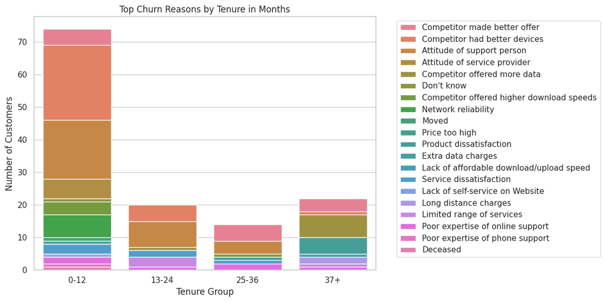

```python
# ========== 2. Top Churn Reasons by Tenure Group ==========
tenure_reason = churned_df.groupby(['Tenure Group', 'Churn Reason'], observed=True).size().reset_index(name='Count')
top_tenure_reasons = tenure_reason.sort_values(['Tenure Group', 'Count'], ascending=[True, False])

plt.figure(figsize=(12, 6))
sns.barplot(data=top_tenure_reasons, x='Tenure Group', y='Count', hue='Churn Reason', dodge=False)
plt.title('Top Churn Reasons by Tenure in Months')
plt.ylabel('Number of Customers')
plt.xticks(rotation=0)
plt.legend(bbox_to_anchor=(1.05, 1), loc='upper left')
plt.tight_layout()
plt.show()
```

```python
tenure_group_0_12_df = df[(df['Tenure in Months'] >= 0) & (df['Tenure in Months'] <= 12)]
churn_reasons_0_12 = tenure_group_0_12_df['Churn Reason'].value_counts()

total_churn_reasons_0_12 = churn_reasons_0_12.sum()
print("\nTotal churn reasons (customers) in tenure group 0-12:", total_churn_reasons_0_12)
top_reasons_0_12 = churn_reasons_0_12.head(100)
print("Top churn reasons for customers (0-12 months):\n", top_reasons_0_12)
```

```
Total churn reasons (customers) in tenure group 0-12: 372
Top churn reasons for customers (0-12 months):
 Churn Reason
Competitor made better offer                 74
Competitor had better devices                69
Attitude of support person                   46
Attitude of service provider                 28
Competitor offered more data                 22
Don't know                                   22
Competitor offered higher download speeds    21
Network reliability                          17
Moved                                        10
Product dissatisfaction                       9
Price too high                                9
Lack of affordable download/upload speed      8
Service dissatisfaction                       8
Extra data charges                            8
Long distance charges                         5
Lack of self-service on Website               5
Limited range of services                     4
Poor expertise of online support              4
Poor expertise of phone support               2
Deceased                                      1
Name: count, dtype: int64
```

```python
tenure_group_13_24_df = df[(df['Tenure in Months'] >= 13) & (df['Tenure in Months'] <= 24)]
churn_reasons_13_24 = tenure_group_13_24_df['Churn Reason'].value_counts()

total_churn_reasons_13_24 = churn_reasons_13_24.sum()
print("\nTotal churn reasons (customers) in tenure group 13-24:", total_churn_reasons_13_24)
top_reasons_13_24 = churn_reasons_13_24.head(100)
print("Top churn reasons for customers (13-24 months):\n", top_reasons_13_24)
```

```
Total churn reasons (customers) in tenure group 13-24: 106
Top churn reasons for customers (13-24 months):
 Churn Reason
Competitor had better devices                20
Attitude of support person                   15
Competitor made better offer                 12
Competitor offered more data                  7
Don't know                                    6
Service dissatisfaction                       6
Competitor offered higher download speeds     5
Attitude of service provider                  5
Network reliability                           4
Limited range of services                     4
Lack of self-service on Website               4
Product dissatisfaction                       3
Long distance charges                         3
Price too high                                3
Moved                                         3
Extra data charges                            3
Lack of affordable download/upload speed      2
Poor expertise of online support              1
Name: count, dtype: int64
```

```python
tenure_group_25_36_df = df[(df['Tenure in Months'] >= 25) & (df['Tenure in Months'] <= 36)]
churn_reasons_25_36 = tenure_group_25_36_df['Churn Reason'].value_counts()

total_churn_reasons_25_36 = churn_reasons_25_36.sum()
print("\nTotal churn reasons (customers) in tenure group 25-36:", total_churn_reasons_25_36)
top_reasons_25_36 = churn_reasons_25_36.head(100)
print("Top churn reasons for customers (25-36 months):\n", top_reasons_25_36)
```

```
Total churn reasons (customers) in tenure group 25-36: 66
Top churn reasons for customers (25-36 months):
 Churn Reason
Competitor made better offer                 14
Attitude of support person                    9
Competitor had better devices                 7
Competitor offered higher download speeds     5
Extra data charges                            4
Competitor offered more data                  4
Price too high                                4
Don't know                                    4
Product dissatisfaction                       3
Service dissatisfaction                       3
Attitude of service provider                  2
Poor expertise of online support              2
Moved                                         2
Long distance charges                         1
Limited range of services                     1
Network reliability                           1
Name: count, dtype: int64
```

```python
tenure_group_37plus_df = df[df['Age'] >= 37]
churn_reasons_37plus = tenure_group_37plus_df['Churn Reason'].value_counts()

total_churn_reasons_37plus = churn_reasons_37plus.sum()
print("\nTotal churn reasons (customers) in tenure group 37+:", total_churn_reasons_37plus)
top_reasons_37plus = churn_reasons_37plus.head(100)
print("Top churn reasons for customers (37+ months):\n", top_reasons_37plus)
```

```
Total churn reasons (customers) in tenure group 37+: 481
Top churn reasons for customers (37+ months):
 Churn Reason
Competitor made better offer                 89
Competitor had better devices                84
Attitude of support person                   53
Competitor offered higher download speeds    30
Competitor offered more data                 28
Don't know                                   27
Attitude of service provider                 27
Price too high                               23
Product dissatisfaction                      20
Network reliability                          18
Moved                                        14
Extra data charges                           14
Lack of affordable download/upload speed     11
Long distance charges                        11
Service dissatisfaction                      10
Limited range of services                     9
Poor expertise of online support              7
Lack of self-service on Website               5
Poor expertise of phone support               1
Name: count, dtype: int64
```

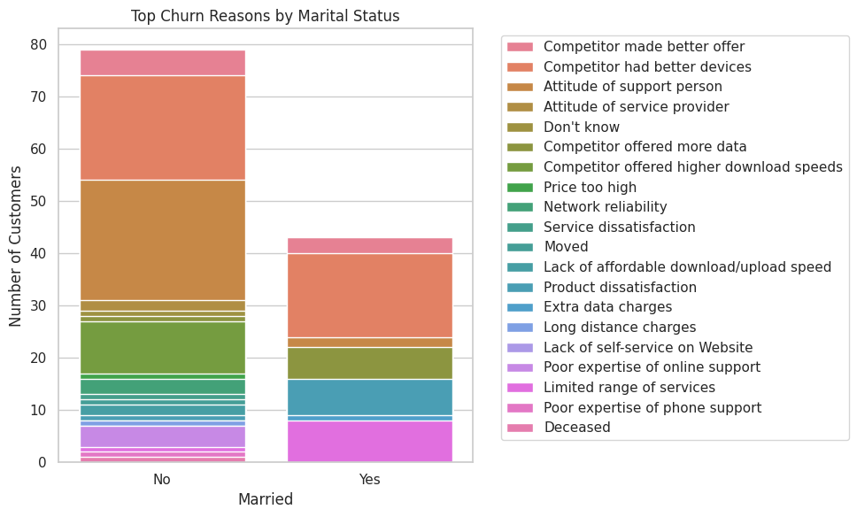

```python
# ========== 3. Top Churn Reasons by Marital Status ==========
marital_reason = churned_df.groupby(['Married', 'Churn Reason'], observed=True).size().reset_index(name='Count')
top_marital_reasons = marital_reason.sort_values(['Married', 'Count'], ascending=[True, False])

plt.figure(figsize=(10, 6))
sns.barplot(data=top_marital_reasons, x='Married', y='Count', hue='Churn Reason', dodge=False)
plt.title('Top Churn Reasons by Marital Status')
plt.ylabel('Number of Customers')
plt.xticks(rotation=0)
plt.legend(bbox_to_anchor=(1.05, 1), loc='upper left')
plt.tight_layout()
plt.show()
```

```python
married_no_df = df[df['Married'] == 'No']
churn_reasons_no = married_no_df['Churn Reason'].value_counts()

total_churn_reasons_no = churn_reasons_no.sum()
print("\nTotal churn reasons of non-married customers:", total_churn_reasons_no)
top_reasons_no = churn_reasons_no.head(100)
print("Top churn reasons for non-married customers:\n", top_reasons_no)
```

```
Total churn reasons of non-married customers: 436
Top churn reasons for non-married customers:
 Churn Reason
Competitor made better offer                 79
Competitor had better devices                74
Attitude of support person                   54
Attitude of service provider                 31
Don't know                                   29
Competitor offered more data                 28
Competitor offered higher download speeds    27
Price too high                               17
Network reliability                          16
Service dissatisfaction                      13
Moved                                        12
Lack of affordable download/upload speed     11
Product dissatisfaction                       9
Long distance charges                         8
Extra data charges                            8
Lack of self-service on Website               7
Poor expertise of online support              7
Limited range of services                     3
Poor expertise of phone support               2
Deceased                                      1
Name: count, dtype: int64
```

```python
married_yes_df = df[df['Married'] == 'Yes']
churn_reasons_yes = married_yes_df['Churn Reason'].value_counts()

total_churn_reasons_yes = churn_reasons_yes.sum()
print("\nTotal churn reasons of married customers:", total_churn_reasons_yes)
top_reasons_yes = churn_reasons_yes.head(100)
print("Top churn reasons for married customers:\n", top_reasons_yes)
```

```
Total churn reasons of married customers: 245
Top churn reasons for married customers:
 Churn Reason
Competitor made better offer                 43
Competitor had better devices                40
Attitude of support person                   24
Competitor offered more data                 22
Product dissatisfaction                      16
Competitor offered higher download speeds    13
Attitude of service provider                 13
Network reliability                          13
Don't know                                    9
Extra data charges                            9
Price too high                                9
Limited range of services                     8
Moved                                         7
Service dissatisfaction                       7
Long distance charges                         5
Lack of affordable download/upload speed      4
Lack of self-service on Website               2
Poor expertise of online support              1
Name: count, dtype: int64
```

## Analysis 3: Churn Rate by Internet Type & Streaming Usage

**Objective:** To compare churn behavior based on customers' internet types and their usage of streaming services, identifying which segments are more likely to churn by analyzing churn vs retained counts and rates.

**Questions:**

1. How does customer churn vary across different internet service types?
2. Is there a relationship between churn rates and usage of streaming services?

> *To answer the questions:*

> Customer churn significantly varies depending on the type of internet service used:
> 1. Fiber Optic has the highest churn rate at 17.33%, suggesting that customers using this high-speed internet may have higher expectations or face pricing or service issues.
> 2. Cable shows a moderate churn rate of 8.31%, possibly due to it being a more stable or affordable option.
> 3. DSL has the lowest churn rate at 5.21%, indicating relatively better customer retention, perhaps due to lower costs or less volatility in service expectations.

> Yes, there appears to be a consistent relationship: All three streaming services have similar churn rates — Streaming Movies (11.60%), Streaming TV (11.56%), and Streaming Music (11.45%).

### Insights

- Customers using faster or premium internet services like Fiber Optic are more prone to churn than those using traditional or slower options like DSL.
- Streaming users are more likely to churn compared to average churn rates, suggesting that customers engaged in high-bandwidth activities like streaming may be more sensitive to service quality or pricing, especially if performance doesn't meet expectations.

### Recommendations

- Ensure consistent speed and reliability by proactively monitoring and upgrading network performance in fiber-enabled areas.
- Introduce exclusive perks such as priority support, streaming service bundles, and home Wi-Fi optimization visits.
- Prioritize traffic shaping and load balancing during peak hours for popular streaming platforms like Netflix, YouTube, etc.
- Provide streaming-optimized plans that guarantee minimum speeds or include unlimited bandwidth during off-peak hours.
- Offer streaming bundles or discounts such as free months of Netflix and Prime Video, as part of higher-tier plans to justify pricing and add stickiness.

```
--- Internet Type & Streaming Usage BEFORE Data Cleaning ---

Internet Type / Streaming Usage  Total Customers
                    Fiber Optic             3035
                            DSL             1652
                          Cable              830
                   Streaming TV             2707
               Streaming Movies             2732
                Streaming Music             2488

--- Internet Type & Streaming Usage AFTER Data Cleaning ---

Internet Type / Streaming Usage  Churned Customers
                    Fiber Optic                526
                            DSL                 86
                          Cable                 69
                   Streaming TV                313
               Streaming Movies                317
                Streaming Music                285

Churn Rate by Internet Type & Streaming Usage:
                   Total Customers  Churned Customers  Churn Rate (%)
Fiber Optic                  3035                526           17.33
DSL                          1652                 86            5.21
Cable                         830                 69            8.31
Streaming TV                 2707                313           11.56
Streaming Movies             2732                317           11.60
Streaming Music              2488                285           11.45
```

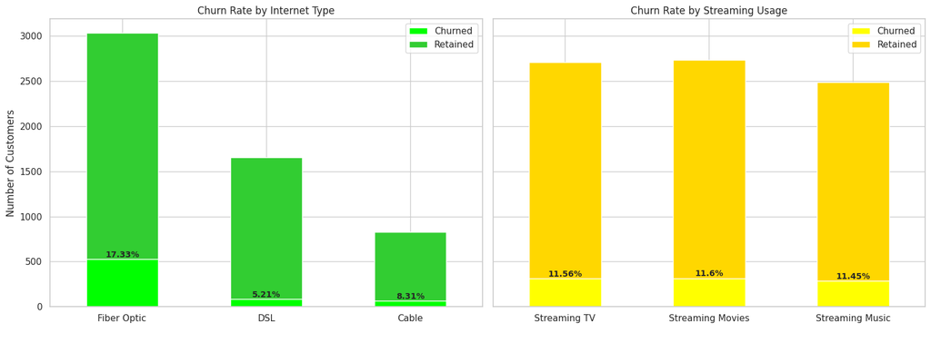

```python
import pandas as pd
import matplotlib.pyplot as plt
import seaborn as sns
from google.colab import drive

drive.mount('/content/drive', force_remount=True)
file_path = '/content/drive/MyDrive/Portfolios/Data-Analyst/Gladys-Lacia-for-Data-Analyst-role/datasets/dataset-Customer-Churn-Telco-California-from-April-to-June-2022.csv'

df = pd.read_csv(file_path, low_memory=False)
df_raw = df.copy()

# --- Combining Internet Type and Streaming Usage Counts (Before Cleaning) ---
internet_type_counts_before = df['Internet Type'].value_counts()
streaming_counts_before = df[['Streaming TV', 'Streaming Movies', 'Streaming Music']].apply(lambda x: x == 'Yes').sum()

counts_before_df = pd.concat([internet_type_counts_before, streaming_counts_before])
counts_before_df = counts_before_df.rename_axis('Internet Type / Streaming Usage').reset_index(name='Total Customers')

print("\n--- Internet Type & Streaming Usage BEFORE Data Cleaning ---\n")
print(counts_before_df.to_string(index=False))

total_customers_by_internet_type = internet_type_counts_before.copy()

# --- Data Cleaning ---
df = df.dropna(subset=['Churn Reason', 'Offer', 'Internet Type', 'Avg Monthly Long Distance Charges'])
churned_df = df[df['Customer Status'] == 'Churned']
streaming_cols = ['Streaming TV', 'Streaming Movies', 'Streaming Music']

# --- Combining Internet Type and Streaming Usage Counts (After Cleaning) ---
internet_type_counts_after = df['Internet Type'].value_counts()
streaming_counts_after = df[['Streaming TV', 'Streaming Movies', 'Streaming Music']].apply(lambda x: x == 'Yes').sum()

counts_after_df = pd.concat([internet_type_counts_after, streaming_counts_after])
counts_after_df = counts_after_df.rename_axis('Internet Type / Streaming Usage').reset_index(name='Churned Customers')

print("\n--- Internet Type & Streaming Usage AFTER Data Cleaning ---\n")
print(counts_after_df.to_string(index=False))

churned_customers_by_internet_type = churned_df['Internet Type'].value_counts()
churned_customers_by_streaming_tv = churned_df['Streaming TV'].value_counts()
churned_customers_by_streaming_movies = churned_df['Streaming Movies'].value_counts()
churned_customers_by_streaming_music = churned_df['Streaming Music'].value_counts()

churn_rate_internet_type = (churned_customers_by_internet_type / total_customers_by_internet_type * 100).round(2)
churn_rate_by_internet_type = pd.DataFrame({
    'Total Customers': total_customers_by_internet_type,
    'Churned Customers': churned_customers_by_internet_type,
    'Churn Rate (%)': churn_rate_internet_type
}).fillna(0).astype({'Churned Customers': 'int'})

streaming_total_before = df_raw[['Streaming TV', 'Streaming Movies', 'Streaming Music']].apply(lambda x: x == 'Yes').sum()
streaming_churned_after = churned_df[['Streaming TV', 'Streaming Movies', 'Streaming Music']].apply(lambda x: x == 'Yes').sum()
churn_rate_streaming_usage = ((streaming_churned_after / streaming_total_before) * 100).round(2)

streaming_df = pd.DataFrame({
    'Total Customers': streaming_total_before,
    'Churned Customers': streaming_churned_after,
    'Churn Rate (%)': churn_rate_streaming_usage
}).astype({'Churned Customers': 'int'})

churn_rate_by_internet_type_and_streaming_usage = pd.concat([
    churn_rate_by_internet_type,
    streaming_df
])

print("\nChurn Rate by Internet Type & Streaming Usage:\n", churn_rate_by_internet_type_and_streaming_usage)

# --- Internet Type Data ---
internet_type_total = df_raw['Internet Type'].value_counts()
internet_type_churned = churned_df['Internet Type'].value_counts()
internet_type_df = pd.DataFrame({
    'Churned': internet_type_churned,
    'Total': internet_type_total
}).fillna(0).astype(int)
internet_type_df['Retained'] = internet_type_df['Total'] - internet_type_df['Churned']
internet_type_df['Churn Rate (%)'] = (internet_type_df['Churned'] / internet_type_df['Total'] * 100).round(2)

# --- Streaming Usage Data ---
streaming_total = df_raw[streaming_cols].apply(lambda x: x == 'Yes').sum()
streaming_churned = churned_df[streaming_cols].apply(lambda x: x == 'Yes').sum()
streaming_df = pd.DataFrame({
    'Churned': streaming_churned,
    'Total': streaming_total
}).astype(int)
streaming_df['Retained'] = streaming_df['Total'] - streaming_df['Churned']
streaming_df['Churn Rate (%)'] = (streaming_df['Churned'] / streaming_df['Total'] * 100).round(2)

# --- Plotting Stacked Bars ---
fig, axes = plt.subplots(1, 2, figsize=(16, 6), sharey=True)

# Internet Type Stack Bars
internet_type_df[['Churned', 'Retained']].plot(
    kind='bar',
    stacked=True,
    ax=axes[0],
    color=['lime', 'limegreen'], rot=0
)
axes[0].set_title("Churn Rate by Internet Type")
axes[0].set_ylabel("Number of Customers")
axes[0].set_xlabel(" ")
axes[0].legend(["Churned", "Retained"])

# churn rate percentages in Internet Type
for idx, row in internet_type_df.iterrows():
    axes[0].text(
        x=internet_type_df.index.get_loc(idx),
        y=row['Churned'] + 20,
        s=f"{row['Churn Rate (%)']}%",
        ha='center',
        fontsize=10,
        fontweight='bold'
    )

# Streaming Usage Stack Bars
streaming_df[['Churned', 'Retained']].plot(
    kind='bar',
    stacked=True,
    ax=axes[1],
    color=['yellow', 'gold'], rot=0
)
axes[1].set_title("Churn Rate by Streaming Usage")
axes[1].set_xlabel(" ")
axes[1].legend(["Churned", "Retained"])

# churn rate percentages in Streaming Usage
for idx, row in streaming_df.iterrows():
    axes[1].text(
        x=streaming_df.index.get_loc(idx),
        y=row['Churned'] + 20,
        s=f"{row['Churn Rate (%)']}%",
        ha='center',
        fontsize=10,
        fontweight='bold'
    )

plt.tight_layout()
plt.show()
```